# Kassin_B_HW_DataVisualization

**Brian Kassin "On my honor, as a student, I have neither given nor received unauthorized aid on this academic work."**

```python
#import python packages (these are the most popular ones)
import pandas as pd
import numpy as np
import matplotlib.pyplot as plt
import seaborn as sns

%matplotlib inline
```

```python
#load the data
df = pd.read_csv("data/bank.csv")
pd.options.display.max_columns = None
df.head(2)
```

|  | CHK_ACCT | DURATION | HISTORY | NEW_CAR | USED_CAR | FURNITURE | RADIO/TV | EDUCATION | RETRAINING | AMOUNT | SAV_ACCT | EMPLOYMENT | INSTALL_RATE | MALE_DIV | MALE_SINGLE | MALE_MAR_or_WID | CO-APPLICANT | GUARANTOR | PRESENT_RESIDENT | REAL_ESTATE | PROP_UNKN_NONE | AGE | OTHER_INSTALL | RENT | OWN_RES | NUM_CREDITS | JOB | NUM_DEPENDENTS | TELEPHONE | … |
| --- | --- | --- | --- | --- | --- | --- | --- | --- | --- | --- | --- | --- | --- | --- | --- | --- | --- | --- | --- | --- | --- | --- | --- | --- | --- | --- | --- | --- | --- | --- |
| 0 | 0 | 6 | 4 | 0 | 0 | 0 | 1 | 0 | 0 | 1169 | 4 | 4 | 4 | 0 | 1 | 0 | 0 | 0 | 4 | 1 | 0 | 67 | 0 | 0 | 1 | 2 | 2 | 1 | 1 | … |
| 1 | 1 | 48 | 2 | 0 | 0 | 0 | 1 | 0 | 0 | 5951 | 0 | 2 | 2 | 0 | 0 | 0 | 0 | 0 | 2 | 1 | 0 | 22 | 0 | 0 | 1 | 1 | 2 | 1 | 0 | … |

```python
df.tail(2)
```

|  | CHK_ACCT | DURATION | HISTORY | NEW_CAR | USED_CAR | FURNITURE | RADIO/TV | EDUCATION | RETRAINING | AMOUNT | SAV_ACCT | EMPLOYMENT | INSTALL_RATE | MALE_DIV | MALE_SINGLE | MALE_MAR_or_WID | CO-APPLICANT | GUARANTOR | PRESENT_RESIDENT | REAL_ESTATE | PROP_UNKN_NONE | AGE | OTHER_INSTALL | RENT | OWN_RES | NUM_CREDITS | JOB | NUM_DEPENDENTS | TELEPHONE | … |
| --- | --- | --- | --- | --- | --- | --- | --- | --- | --- | --- | --- | --- | --- | --- | --- | --- | --- | --- | --- | --- | --- | --- | --- | --- | --- | --- | --- | --- | --- | --- |
| 998 | 0 | 45 | 2 | 0 | 0 | 0 | 1 | 0 | 0 | 1845 | 0 | 2 | 4 | 0 | 1 | 0 | 0 | 0 | 4 | 0 | 1 | 23 | 0 | 0 | 0 | 1 | 2 | 1 | 1 | … |
| 999 | 1 | 45 | 4 | 0 | 1 | 0 | 0 | 0 | 0 | 4576 | 1 | 0 | 3 | 0 | 1 | 0 | 0 | 0 | 4 | 0 | 0 | 27 | 0 | 0 | 1 | 1 | 2 | 1 | 0 | … |

```python
df.isnull().sum()
```

```
CHK_ACCT            0
DURATION            0
HISTORY             0
NEW_CAR             0
USED_CAR            0
FURNITURE           0
RADIO/TV            0
EDUCATION           0
RETRAINING          0
AMOUNT              0
SAV_ACCT            0
EMPLOYMENT          0
INSTALL_RATE        0
MALE_DIV            0
MALE_SINGLE         0
MALE_MAR_or_WID     0
CO-APPLICANT        0
GUARANTOR           0
PRESENT_RESIDENT    0
REAL_ESTATE         0
PROP_UNKN_NONE      0
AGE                 0
OTHER_INSTALL       0
RENT                0
OWN_RES             0
NUM_CREDITS         0
JOB                 0
NUM_DEPENDENTS      0
TELEPHONE           0
FOREIGN             0
RESPONSE            0
dtype: int64
```

```python
df.info()
```

```
<class 'pandas.core.frame.DataFrame'>
RangeIndex: 1000 entries, 0 to 999
Data columns (total 31 columns):
CHK_ACCT            1000 non-null int64
DURATION            1000 non-null int64
HISTORY             1000 non-null int64
NEW_CAR             1000 non-null int64
USED_CAR            1000 non-null int64
FURNITURE           1000 non-null int64
RADIO/TV            1000 non-null int64
EDUCATION           1000 non-null int64
RETRAINING          1000 non-null int64
AMOUNT              1000 non-null int64
SAV_ACCT            1000 non-null int64
EMPLOYMENT          1000 non-null int64
INSTALL_RATE        1000 non-null int64
MALE_DIV            1000 non-null int64
MALE_SINGLE         1000 non-null int64
MALE_MAR_or_WID     1000 non-null int64
CO-APPLICANT        1000 non-null int64
GUARANTOR           1000 non-null int64
PRESENT_RESIDENT    1000 non-null int64
REAL_ESTATE         1000 non-null int64
PROP_UNKN_NONE      1000 non-null int64
AGE                 1000 non-null int64
OTHER_INSTALL       1000 non-null int64
RENT                1000 non-null int64
OWN_RES             1000 non-null int64
NUM_CREDITS         1000 non-null int64
JOB                 1000 non-null int64
NUM_DEPENDENTS      1000 non-null int64
TELEPHONE           1000 non-null int64
FOREIGN             1000 non-null int64
RESPONSE            1000 non-null int64
dtypes: int64(31)
memory usage: 242.3 KB
```

# Use some common sense (and/or your business knowledge) to answer the first question. Which columns or (independent) variables would significantly influence the Y value (whether someone fulfills the terms of credit agreement or not)? List at least three and explain why?

## Name the column (variable) and explain why?

CHK_ACCT is a column or (independent) variable that would significantly influence the Y value because people with more accounts are able to pay back loans more quickly as they are better able to manage their money

## Name the column (variable) and explain why?

DURATION is a column or (independent) variable that would significantly influence the Y value because the longer the duration the less likely the person is going to pay back the full amount

## Name the column (variable) and explain why?

AMOUNT is a column or (independent) variable that would significantly influence the Y value because the higher the amount the less likely the person is going to pay back the full amount as it will have a longer duration

# What are some general findings from basic statistics (describe)?

```python
df.describe()
```

|  | CHK_ACCT | DURATION | HISTORY | NEW_CAR | USED_CAR | FURNITURE | RADIO/TV | EDUCATION | RETRAINING | AMOUNT | SAV_ACCT | EMPLOYMENT | INSTALL_RATE | MALE_DIV | MALE_SINGLE | MALE_MAR_or_WID | CO-APPLICANT | GUARANTOR | PRESENT_RESIDENT | REAL_ESTATE | PROP_UNKN_NONE | AGE | OTHER_INSTALL | RENT | OWN_RES | NUM_CREDITS | JOB | NUM_DEPENDENTS | TELEPHONE | … |
| --- | --- | --- | --- | --- | --- | --- | --- | --- | --- | --- | --- | --- | --- | --- | --- | --- | --- | --- | --- | --- | --- | --- | --- | --- | --- | --- | --- | --- | --- | --- |
| count | 1000.000000 | 1000.000000 | 1000.00000 | 1000.000000 | 1000.000000 | 1000.000000 | 1000.000000 | 1000.000000 | 1000.000000 | 1000.000000 | 1000.000000 | 1000.000000 | 1000.000000 | 1000.000000 | 1000.00000 | 1000.000000 | 1000.000000 | 1000.000000 | 1000.000000 | 1000.000000 | 1000.000000 | 1000.000000 | 1000.000000 | 1000.000000 | 1000.000000 | 1000.000000 | 1000.000000 | 1000.000000 | 1000.000000 | … |
| mean | 1.577000 | 20.903000 | 2.54500 | 0.234000 | 0.103000 | 0.181000 | 0.280000 | 0.050000 | 0.097000 | 3271.258000 | 1.105000 | 2.384000 | 2.973000 | 0.050000 | 0.54800 | 0.092000 | 0.041000 | 0.052000 | 2.845000 | 0.282000 | 0.154000 | 35.546000 | 0.186000 | 0.179000 | 0.713000 | 1.407000 | 1.904000 | 1.155000 | 0.404000 | … |
| std | 1.257638 | 12.058814 | 1.08312 | 0.423584 | 0.304111 | 0.385211 | 0.449224 | 0.218054 | 0.296106 | 2822.736876 | 1.580023 | 1.208306 | 1.118715 | 0.218054 | 0.49794 | 0.289171 | 0.198389 | 0.222138 | 1.103718 | 0.450198 | 0.361129 | 11.375469 | 0.389301 | 0.383544 | 0.452588 | 0.577654 | 0.653614 | 0.362086 | 0.490943 | … |
| min | 0.000000 | 4.000000 | 0.00000 | 0.000000 | 0.000000 | 0.000000 | 0.000000 | 0.000000 | 0.000000 | 250.000000 | 0.000000 | 0.000000 | 1.000000 | 0.000000 | 0.00000 | 0.000000 | 0.000000 | 0.000000 | 1.000000 | 0.000000 | 0.000000 | 19.000000 | 0.000000 | 0.000000 | 0.000000 | 1.000000 | 0.000000 | 1.000000 | 0.000000 | … |
| 25% | 0.000000 | 12.000000 | 2.00000 | 0.000000 | 0.000000 | 0.000000 | 0.000000 | 0.000000 | 0.000000 | 1365.500000 | 0.000000 | 2.000000 | 2.000000 | 0.000000 | 0.00000 | 0.000000 | 0.000000 | 0.000000 | 2.000000 | 0.000000 | 0.000000 | 27.000000 | 0.000000 | 0.000000 | 0.000000 | 1.000000 | 2.000000 | 1.000000 | 0.000000 | … |
| 50% | 1.000000 | 18.000000 | 2.00000 | 0.000000 | 0.000000 | 0.000000 | 0.000000 | 0.000000 | 0.000000 | 2319.500000 | 0.000000 | 2.000000 | 3.000000 | 0.000000 | 1.00000 | 0.000000 | 0.000000 | 0.000000 | 3.000000 | 0.000000 | 0.000000 | 33.000000 | 0.000000 | 0.000000 | 1.000000 | 1.000000 | 2.000000 | 1.000000 | 0.000000 | … |
| 75% | 3.000000 | 24.000000 | 4.00000 | 0.000000 | 0.000000 | 0.000000 | 1.000000 | 0.000000 | 0.000000 | 3972.250000 | 2.000000 | 4.000000 | 4.000000 | 0.000000 | 1.00000 | 0.000000 | 0.000000 | 0.000000 | 4.000000 | 1.000000 | 0.000000 | 42.000000 | 0.000000 | 0.000000 | 1.000000 | 2.000000 | 2.000000 | 1.000000 | 1.000000 | … |
| max | 3.000000 | 72.000000 | 4.00000 | 1.000000 | 1.000000 | 1.000000 | 1.000000 | 1.000000 | 1.000000 | 18424.000000 | 4.000000 | 4.000000 | 4.000000 | 1.000000 | 1.00000 | 1.000000 | 1.000000 | 1.000000 | 4.000000 | 1.000000 | 1.000000 | 75.000000 | 1.000000 | 1.000000 | 1.000000 | 4.000000 | 3.000000 | 2.000000 | 1.000000 | … |

## What is the average number of checking account?

```python
len(df)
```

```
1000
```

```python
df.columns
```

```
Index(['CHK_ACCT', 'DURATION', 'HISTORY', 'NEW_CAR', 'USED_CAR', 'FURNITURE',
       'RADIO/TV', 'EDUCATION', 'RETRAINING', 'AMOUNT', 'SAV_ACCT',
       'EMPLOYMENT', 'INSTALL_RATE', 'MALE_DIV', 'MALE_SINGLE',
       'MALE_MAR_or_WID', 'CO-APPLICANT', 'GUARANTOR', 'PRESENT_RESIDENT',
       'REAL_ESTATE', 'PROP_UNKN_NONE', 'AGE', 'OTHER_INSTALL', 'RENT',
       'OWN_RES', 'NUM_CREDITS', 'JOB', 'NUM_DEPENDENTS', 'TELEPHONE',
       'FOREIGN', 'RESPONSE'],
      dtype='object')
```

```python
df.groupby('CHK_ACCT').size()
```

```
CHK_ACCT
0    274
1    269
2     63
3    394
dtype: int64
```

```python
df['CHK_ACCT'].mean()
```

```
1.577
```

## What is the maximum loan duration?

```python
df['DURATION'].max()
```

```
72
```

## What was the minimum loan amount?

```python
df['AMOUNT'].min()
```

```
250
```

# What portion of borrowers have paid back? What portion have defaulted on their loans? You need to use a pivot table or charts. Provide a discussion of the findings in a markdown

```python
df.groupby('RESPONSE').size()
```

```
RESPONSE
0    300
1    700
dtype: int64
```

```python
len(df)
```

```
1000
```

```python
df.groupby('RESPONSE').size() / len(df)
```

```
RESPONSE
0    0.3
1    0.7
dtype: float64
```

## Show at least one pie plot

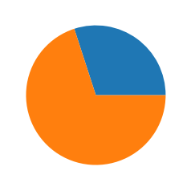

```python
plt.pie(df.groupby('RESPONSE').size());
```

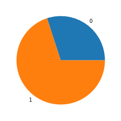

```python
g = df.groupby('RESPONSE').size().reset_index()
plt.pie(g[0], labels=g['RESPONSE']);
```

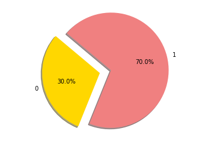

```python
# pie plot

colors = ['gold', 'lightcoral']
explode = (0.2, 0)  # explode 1st slice

plt.pie(g[0], labels=g['RESPONSE'], explode=explode, colors=colors, autopct='%1.1f%%', shadow=True, startangle=140)

plt.axis('equal');
```

## Show at least one bar plot

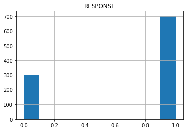

```python
df.hist('RESPONSE');
```

# Demonstrate your skills in groupby to extract business intelligence. The focus of your analysis should be who is likely to pay back/default on the loan. Provide a discussion of the findings in a markdown.

```python
df.groupby('RESPONSE').size()
```

```
RESPONSE
0    300
1    700
dtype: int64
```

```python
# find out general characteristics
df.groupby('RESPONSE').mean()
```

| RESPONSE | CHK_ACCT | DURATION | HISTORY | NEW_CAR | USED_CAR | FURNITURE | RADIO/TV | EDUCATION | RETRAINING | AMOUNT | SAV_ACCT | EMPLOYMENT | INSTALL_RATE | MALE_DIV | MALE_SINGLE | MALE_MAR_or_WID | CO-APPLICANT | GUARANTOR | PRESENT_RESIDENT | REAL_ESTATE | PROP_UNKN_NONE | AGE | OTHER_INSTALL | RENT | OWN_RES | NUM_CREDITS | JOB | NUM_DEPENDENTS | TELEPHONE | … |
| --- | --- | --- | --- | --- | --- | --- | --- | --- | --- | --- | --- | --- | --- | --- | --- | --- | --- | --- | --- | --- | --- | --- | --- | --- | --- | --- | --- | --- | --- | --- |
| 0 | 0.903333 | 24.860000 | 2.166667 | 0.296667 | 0.056667 | 0.193333 | 0.206667 | 0.073333 | 0.113333 | 3938.126667 | 0.673333 | 2.170000 | 3.096667 | 0.066667 | 0.486667 | 0.083333 | 0.060000 | 0.033333 | 2.850000 | 0.200000 | 0.223333 | 33.963333 | 0.253333 | 0.233333 | 0.620000 | 1.366667 | 1.936667 | 1.153333 | 0.376667 | … |
| 1 | 1.865714 | 19.207143 | 2.707143 | 0.207143 | 0.122857 | 0.175714 | 0.311429 | 0.040000 | 0.090000 | 2985.457143 | 1.290000 | 2.475714 | 2.920000 | 0.042857 | 0.574286 | 0.095714 | 0.032857 | 0.060000 | 2.842857 | 0.317143 | 0.124286 | 36.224286 | 0.157143 | 0.155714 | 0.752857 | 1.424286 | 1.890000 | 1.155714 | 0.415714 | … |

Findings:

- the higher duration, the riskier
- the higher loan amount, the riskier

# Demonstrate your skills in pivot_table to extract business intelligence. The focus of your analysis should be who is likely to pay back/default on the loan. Provide a discussion of the findings in a markdown.

```python
pd.pivot_table(df, index='RESPONSE', columns='DURATION', values='AMOUNT', aggfunc='mean')
```

| DURATION RESPONSE | 4 | 5 | 6 | 7 | 8 | 9 | 10 | 11 | 12 | 13 | 14 | 15 | 16 | 18 | 20 | 21 | 22 | 24 | 26 | 27 | 28 | 30 | 33 | 36 | 39 | 40 | 42 | 45 | 47 | … |
| --- | --- | --- | --- | --- | --- | --- | --- | --- | --- | --- | --- | --- | --- | --- | --- | --- | --- | --- | --- | --- | --- | --- | --- | --- | --- | --- | --- | --- | --- | --- |
| 0 | NaN | NaN | 4629.444444 | NaN | 1237.000000 | 1552.285714 | 1586.333333 | NaN | 1718.163265 | NaN | 8978.000000 | 2436.833333 | 2625.0 | 2627.785714 | 2235.000000 | 3714.777778 | NaN | 3331.357143 | NaN | 4523.200 | 4006.0 | 4839.538462 | 4281.0 | 6013.297297 | 4933.0 | 5998.0 | 5169.666667 | 5359.5 | NaN | … |
| 1 | 1662.833333 | 3448.0 | 1400.227273 | 1779.2 | 1395.666667 | 1779.685714 | 1925.280000 | 3047.888889 | 1813.561538 | 1547.25 | 2061.666667 | 2165.250000 | 1175.0 | 2771.901408 | 4610.142857 | 2798.714286 | 1979.0 | 3205.140625 | 7966.0 | 4724.625 | 5283.5 | 4328.222222 | 5008.5 | 5534.934783 | 9274.0 | NaN | 6100.750000 | 4576.0 | 10722.0 | … |

```python
pd.pivot_table(df, index='RESPONSE', columns='DURATION', values='AMOUNT', aggfunc='count')
```

| DURATION RESPONSE | 4 | 5 | 6 | 7 | 8 | 9 | 10 | 11 | 12 | 13 | 14 | 15 | 16 | 18 | 20 | 21 | 22 | 24 | 26 | 27 | 28 | 30 | 33 | 36 | 39 | 40 | 42 | 45 | 47 | … |
| --- | --- | --- | --- | --- | --- | --- | --- | --- | --- | --- | --- | --- | --- | --- | --- | --- | --- | --- | --- | --- | --- | --- | --- | --- | --- | --- | --- | --- | --- | --- |
| 0 | NaN | NaN | 9.0 | NaN | 1.0 | 14.0 | 3.0 | NaN | 49.0 | NaN | 1.0 | 12.0 | 1.0 | 42.0 | 1.0 | 9.0 | NaN | 56.0 | NaN | 5.0 | 1.0 | 13.0 | 1.0 | 37.0 | 1.0 | 1.0 | 3.0 | 4.0 | NaN | … |
| 1 | 6.0 | 1.0 | 66.0 | 5.0 | 6.0 | 35.0 | 25.0 | 9.0 | 130.0 | 4.0 | 3.0 | 52.0 | 1.0 | 71.0 | 7.0 | 21.0 | 2.0 | 128.0 | 1.0 | 8.0 | 2.0 | 27.0 | 2.0 | 46.0 | 4.0 | NaN | 8.0 | 1.0 | 1.0 | … |

```python
df.groupby(['RESPONSE', 'EDUCATION']).mean()
```

| RESPONSE | EDUCATION | CHK_ACCT | DURATION | HISTORY | NEW_CAR | USED_CAR | FURNITURE | RADIO/TV | RETRAINING | AMOUNT | SAV_ACCT | EMPLOYMENT | INSTALL_RATE | MALE_DIV | MALE_SINGLE | MALE_MAR_or_WID | CO-APPLICANT | GUARANTOR | PRESENT_RESIDENT | REAL_ESTATE | PROP_UNKN_NONE | AGE | OTHER_INSTALL | RENT | OWN_RES | NUM_CREDITS | JOB | NUM_DEPENDENTS | TELEPHONE | … |
| --- | --- | --- | --- | --- | --- | --- | --- | --- | --- | --- | --- | --- | --- | --- | --- | --- | --- | --- | --- | --- | --- | --- | --- | --- | --- | --- | --- | --- | --- | --- |
| 0 | 0 | 0.899281 | 24.967626 | 2.136691 | 0.320144 | 0.061151 | 0.208633 | 0.223022 | 0.122302 | 3992.255396 | 0.679856 | 2.161871 | 3.064748 | 0.068345 | 0.482014 | 0.089928 | 0.064748 | 0.035971 | 2.834532 | 0.208633 | 0.205036 | 33.884892 | 0.251799 | 0.241007 | 0.625899 | 1.377698 | 1.935252 | 1.147482 | 0.377698 | … |
|  | 1 | 0.954545 | 23.500000 | 2.545455 | 0.000000 | 0.000000 | 0.000000 | 0.000000 | 0.000000 | 3254.136364 | 0.590909 | 2.272727 | 3.500000 | 0.045455 | 0.545455 | 0.000000 | 0.000000 | 0.000000 | 3.045455 | 0.090909 | 0.454545 | 34.954545 | 0.272727 | 0.136364 | 0.545455 | 1.227273 | 1.954545 | 1.227273 | 0.363636 | … |
| 1 | 0 | 1.854167 | 19.206845 | 2.694940 | 0.215774 | 0.127976 | 0.183036 | 0.324405 | 0.093750 | 2979.748512 | 1.275298 | 2.468750 | 2.919643 | 0.044643 | 0.575893 | 0.098214 | 0.034226 | 0.062500 | 2.834821 | 0.327381 | 0.114583 | 35.980655 | 0.157738 | 0.153274 | 0.763393 | 1.421131 | 1.891369 | 1.153274 | 0.412202 | … |
|  | 1 | 2.142857 | 19.214286 | 3.000000 | 0.000000 | 0.000000 | 0.000000 | 0.000000 | 0.000000 | 3122.464286 | 1.642857 | 2.642857 | 2.928571 | 0.000000 | 0.535714 | 0.035714 | 0.000000 | 0.000000 | 3.035714 | 0.071429 | 0.357143 | 42.071429 | 0.142857 | 0.214286 | 0.500000 | 1.500000 | 1.857143 | 1.214286 | 0.500000 | … |

```python
df.groupby('EDUCATION').mean()
```

| EDUCATION | CHK_ACCT | DURATION | HISTORY | NEW_CAR | USED_CAR | FURNITURE | RADIO/TV | RETRAINING | AMOUNT | SAV_ACCT | EMPLOYMENT | INSTALL_RATE | MALE_DIV | MALE_SINGLE | MALE_MAR_or_WID | CO-APPLICANT | GUARANTOR | PRESENT_RESIDENT | REAL_ESTATE | PROP_UNKN_NONE | AGE | OTHER_INSTALL | RENT | OWN_RES | NUM_CREDITS | JOB | NUM_DEPENDENTS | TELEPHONE | FOREIGN | … |
| --- | --- | --- | --- | --- | --- | --- | --- | --- | --- | --- | --- | --- | --- | --- | --- | --- | --- | --- | --- | --- | --- | --- | --- | --- | --- | --- | --- | --- | --- | --- |
| 0 | 1.574737 | 20.892632 | 2.531579 | 0.246316 | 0.108421 | 0.190526 | 0.294737 | 0.102105 | 3276.04 | 1.101053 | 2.378947 | 2.962105 | 0.051579 | 0.548421 | 0.095789 | 0.043158 | 0.054737 | 2.834737 | 0.292632 | 0.141053 | 35.367368 | 0.185263 | 0.178947 | 0.723158 | 1.408421 | 1.904211 | 1.151579 | 0.402105 | 0.038947 | … |
| 1 | 1.620000 | 21.100000 | 2.800000 | 0.000000 | 0.000000 | 0.000000 | 0.000000 | 0.000000 | 3180.40 | 1.180000 | 2.480000 | 3.180000 | 0.020000 | 0.540000 | 0.020000 | 0.000000 | 0.000000 | 3.040000 | 0.080000 | 0.400000 | 38.940000 | 0.200000 | 0.180000 | 0.520000 | 1.380000 | 1.900000 | 1.220000 | 0.440000 | 0.000000 | … |

Findings:

- the higher duration, the riskier
- Those who didn't repay their loans borrowed a higher amount on average
- Those who didn't repay their loans were younger than those who did on average

# What is the relationship between RESPONSE and the three variables you chosen in Question #1? For each variable, you need to show a chart or charts.

## The relationship between RESPONSE and variable #1

```python
df.groupby(['RESPONSE', 'CHK_ACCT']).count()
```

| RESPONSE | CHK_ACCT | DURATION | HISTORY | NEW_CAR | USED_CAR | FURNITURE | RADIO/TV | EDUCATION | RETRAINING | AMOUNT | SAV_ACCT | EMPLOYMENT | INSTALL_RATE | MALE_DIV | MALE_SINGLE | MALE_MAR_or_WID | CO-APPLICANT | GUARANTOR | PRESENT_RESIDENT | REAL_ESTATE | PROP_UNKN_NONE | AGE | OTHER_INSTALL | RENT | OWN_RES | NUM_CREDITS | JOB | NUM_DEPENDENTS | TELEPHONE | … |
| --- | --- | --- | --- | --- | --- | --- | --- | --- | --- | --- | --- | --- | --- | --- | --- | --- | --- | --- | --- | --- | --- | --- | --- | --- | --- | --- | --- | --- | --- | --- |
| 0 | 0 | 135 | 135 | 135 | 135 | 135 | 135 | 135 | 135 | 135 | 135 | 135 | 135 | 135 | 135 | 135 | 135 | 135 | 135 | 135 | 135 | 135 | 135 | 135 | 135 | 135 | 135 | 135 | 135 | … |
|  | 1 | 105 | 105 | 105 | 105 | 105 | 105 | 105 | 105 | 105 | 105 | 105 | 105 | 105 | 105 | 105 | 105 | 105 | 105 | 105 | 105 | 105 | 105 | 105 | 105 | 105 | 105 | 105 | 105 | … |
|  | 2 | 14 | 14 | 14 | 14 | 14 | 14 | 14 | 14 | 14 | 14 | 14 | 14 | 14 | 14 | 14 | 14 | 14 | 14 | 14 | 14 | 14 | 14 | 14 | 14 | 14 | 14 | 14 | 14 | … |
|  | 3 | 46 | 46 | 46 | 46 | 46 | 46 | 46 | 46 | 46 | 46 | 46 | 46 | 46 | 46 | 46 | 46 | 46 | 46 | 46 | 46 | 46 | 46 | 46 | 46 | 46 | 46 | 46 | 46 | … |
| 1 | 0 | 139 | 139 | 139 | 139 | 139 | 139 | 139 | 139 | 139 | 139 | 139 | 139 | 139 | 139 | 139 | 139 | 139 | 139 | 139 | 139 | 139 | 139 | 139 | 139 | 139 | 139 | 139 | 139 | … |
|  | 1 | 164 | 164 | 164 | 164 | 164 | 164 | 164 | 164 | 164 | 164 | 164 | 164 | 164 | 164 | 164 | 164 | 164 | 164 | 164 | 164 | 164 | 164 | 164 | 164 | 164 | 164 | 164 | 164 | … |
|  | 2 | 49 | 49 | 49 | 49 | 49 | 49 | 49 | 49 | 49 | 49 | 49 | 49 | 49 | 49 | 49 | 49 | 49 | 49 | 49 | 49 | 49 | 49 | 49 | 49 | 49 | 49 | 49 | 49 | … |
|  | 3 | 348 | 348 | 348 | 348 | 348 | 348 | 348 | 348 | 348 | 348 | 348 | 348 | 348 | 348 | 348 | 348 | 348 | 348 | 348 | 348 | 348 | 348 | 348 | 348 | 348 | 348 | 348 | 348 | … |

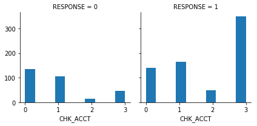

```python
# FaceGrid
g = sns.FacetGrid(df, col="RESPONSE")
g.map(plt.hist, "CHK_ACCT");
```

## The relationship between RESPONSE and variable #2

```python
df.groupby(['RESPONSE', 'DURATION']).count().head()
```

| RESPONSE | DURATION | CHK_ACCT | HISTORY | NEW_CAR | USED_CAR | FURNITURE | RADIO/TV | EDUCATION | RETRAINING | AMOUNT | SAV_ACCT | EMPLOYMENT | INSTALL_RATE | MALE_DIV | MALE_SINGLE | MALE_MAR_or_WID | CO-APPLICANT | GUARANTOR | PRESENT_RESIDENT | REAL_ESTATE | PROP_UNKN_NONE | AGE | OTHER_INSTALL | RENT | OWN_RES | NUM_CREDITS | JOB | NUM_DEPENDENTS | TELEPHONE | … |
| --- | --- | --- | --- | --- | --- | --- | --- | --- | --- | --- | --- | --- | --- | --- | --- | --- | --- | --- | --- | --- | --- | --- | --- | --- | --- | --- | --- | --- | --- | --- |
| 0 | 6 | 9 | 9 | 9 | 9 | 9 | 9 | 9 | 9 | 9 | 9 | 9 | 9 | 9 | 9 | 9 | 9 | 9 | 9 | 9 | 9 | 9 | 9 | 9 | 9 | 9 | 9 | 9 | 9 | … |
|  | 8 | 1 | 1 | 1 | 1 | 1 | 1 | 1 | 1 | 1 | 1 | 1 | 1 | 1 | 1 | 1 | 1 | 1 | 1 | 1 | 1 | 1 | 1 | 1 | 1 | 1 | 1 | 1 | 1 | … |
|  | 9 | 14 | 14 | 14 | 14 | 14 | 14 | 14 | 14 | 14 | 14 | 14 | 14 | 14 | 14 | 14 | 14 | 14 | 14 | 14 | 14 | 14 | 14 | 14 | 14 | 14 | 14 | 14 | 14 | … |
|  | 10 | 3 | 3 | 3 | 3 | 3 | 3 | 3 | 3 | 3 | 3 | 3 | 3 | 3 | 3 | 3 | 3 | 3 | 3 | 3 | 3 | 3 | 3 | 3 | 3 | 3 | 3 | 3 | 3 | … |
|  | 12 | 49 | 49 | 49 | 49 | 49 | 49 | 49 | 49 | 49 | 49 | 49 | 49 | 49 | 49 | 49 | 49 | 49 | 49 | 49 | 49 | 49 | 49 | 49 | 49 | 49 | 49 | 49 | 49 | … |

```python
# FaceGrid
g = sns.FacetGrid(df, col="RESPONSE")
g.map(plt.hist, "DURATION");
```

[output not shown]

## The relationship between RESPONSE and variable #3

```python
df.groupby(['RESPONSE', 'AMOUNT']).mean().head()
```

| RESPONSE | AMOUNT | CHK_ACCT | DURATION | HISTORY | NEW_CAR | USED_CAR | FURNITURE | RADIO/TV | EDUCATION | RETRAINING | SAV_ACCT | EMPLOYMENT | INSTALL_RATE | MALE_DIV | MALE_SINGLE | MALE_MAR_or_WID | CO-APPLICANT | GUARANTOR | PRESENT_RESIDENT | REAL_ESTATE | PROP_UNKN_NONE | AGE | OTHER_INSTALL | RENT | OWN_RES | NUM_CREDITS | JOB | NUM_DEPENDENTS | TELEPHONE | … |
| --- | --- | --- | --- | --- | --- | --- | --- | --- | --- | --- | --- | --- | --- | --- | --- | --- | --- | --- | --- | --- | --- | --- | --- | --- | --- | --- | --- | --- | --- | --- |
| 0 | 433 | 2.0 | 12.0 | 1.5 | 0.0 | 0.0 | 0.0 | 0.5 | 0.5 | 0.0 | 1.5 | 0.5 | 3.5 | 0.0 | 0.0 | 0.0 | 0.5 | 0.0 | 3.0 | 0.5 | 0.0 | 23.0 | 0.5 | 1.0 | 0.0 | 1.0 | 2.0 | 1.5 | 0.0 | … |
|  | 448 | 0.0 | 6.0 | 2.0 | 0.0 | 0.0 | 0.0 | 0.0 | 1.0 | 0.0 | 0.0 | 1.0 | 4.0 | 0.0 | 0.0 | 0.0 | 0.0 | 0.0 | 4.0 | 0.0 | 0.0 | 23.0 | 0.0 | 0.0 | 1.0 | 1.0 | 2.0 | 1.0 | 0.0 | … |
|  | 609 | 2.0 | 12.0 | 1.0 | 0.0 | 0.0 | 0.0 | 0.0 | 0.0 | 1.0 | 0.0 | 1.0 | 4.0 | 0.0 | 0.0 | 0.0 | 0.0 | 0.0 | 1.0 | 1.0 | 0.0 | 26.0 | 0.0 | 0.0 | 1.0 | 1.0 | 0.0 | 1.0 | 0.0 | … |
|  | 626 | 0.0 | 12.0 | 1.0 | 0.0 | 0.0 | 0.0 | 1.0 | 0.0 | 0.0 | 0.0 | 2.0 | 4.0 | 0.0 | 0.0 | 0.0 | 0.0 | 0.0 | 4.0 | 1.0 | 0.0 | 24.0 | 1.0 | 0.0 | 1.0 | 1.0 | 1.0 | 1.0 | 0.0 | … |
|  | 639 | 1.0 | 12.0 | 2.0 | 0.0 | 0.0 | 0.0 | 0.0 | 0.0 | 0.0 | 0.0 | 2.0 | 4.0 | 0.0 | 1.0 | 0.0 | 0.0 | 0.0 | 2.0 | 0.0 | 0.0 | 30.0 | 0.0 | 0.0 | 1.0 | 1.0 | 2.0 | 1.0 | 0.0 | … |

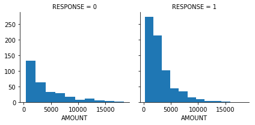

```python
# FaceGrid
g = sns.FacetGrid(df, col="RESPONSE")
g.map(plt.hist, "AMOUNT");
```

## Provide a discussion of the findings in a markdown

Findings:

- The more checking accounts, the likelier they are to pay the loan back
- Longer duration loans are riskier and less likely to be repaid than short-term loans
- Small amount loans are much more likely to be repaid than large amount loans

# Visualize the relationship between DURATION and RESPONSE and provide the insights from the chart(s)?

```python
# FaceGrid
g = sns.FacetGrid(df, col="RESPONSE")
g.map(plt.hist, "DURATION");
```

[output not shown]

## Provide a discussion of the findings in a markdown

Findings:

- Longer duration loans are riskier and less likely to be repaid than short-term loans

# What variables appear to be highly influential in determining Y value (RESPONSE)? Use seaborn charts (e.g., factorplot, lmplot) to answer this question.

## Show at least one factorplot

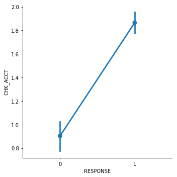

```python
sns.catplot("RESPONSE", "CHK_ACCT", data=df, kind='point');
```

## Show at least one lmplot

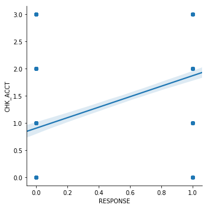

```python
sns.lmplot("RESPONSE", "CHK_ACCT", df);
```

## Show at least one Regression plot

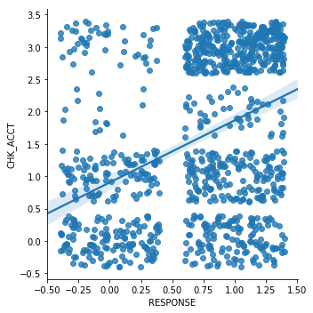

```python
sns.lmplot("RESPONSE", "CHK_ACCT", df, y_jitter=0.40, x_jitter=.40);
```

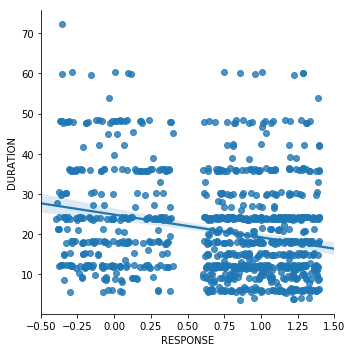

```python
sns.lmplot("RESPONSE", "DURATION", df, y_jitter=0.40, x_jitter=.40);
```

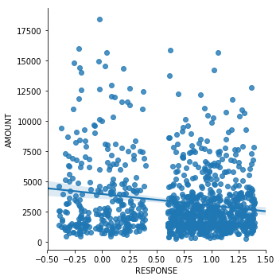

```python
sns.lmplot("RESPONSE", "AMOUNT", df, y_jitter=0.40, x_jitter=.40);
```

## Show at least one jointplot

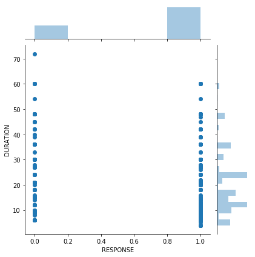

```python
sns.jointplot("RESPONSE", "DURATION", df);
```

## Show at least one FaceGrid

```python
# FaceGrid
g = sns.FacetGrid(df, col="RESPONSE")
g.map(plt.hist, "DURATION");
```

[output not shown]

## Show at least one pairplot

```python
data = pd.concat([df['CHK_ACCT'], df['DURATION'], df['HISTORY']], axis=1)
data.head()
```

|  | CHK_ACCT | DURATION | HISTORY |
| --- | --- | --- | --- |
| 0 | 0 | 6 | 4 |
| 1 | 1 | 48 | 2 |
| 2 | 3 | 12 | 4 |
| 3 | 0 | 42 | 2 |
| 4 | 0 | 24 | 3 |

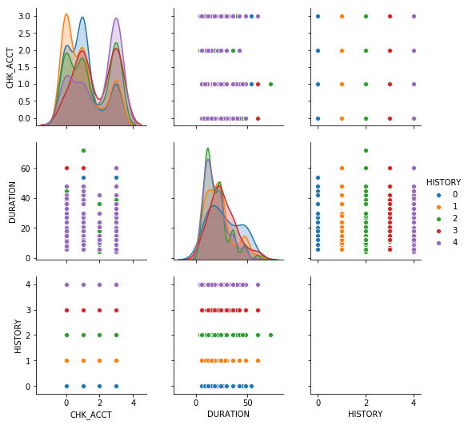

```python
sns.pairplot(data, hue='HISTORY');
```

## Show at least one density plot (e.g., kde)

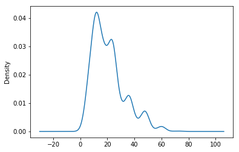

```python
df['DURATION'].plot.kde();
```

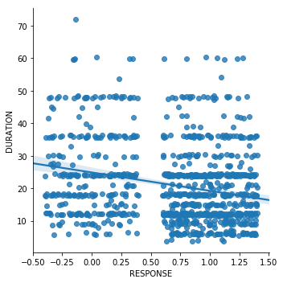

```python
# distplot

sns.lmplot("RESPONSE", "DURATION", df, y_jitter=0.40, x_jitter=.40);
```

## Show at least one violin plot

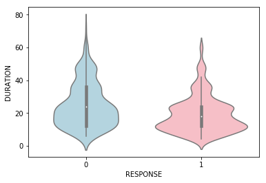

```python
sns.violinplot("RESPONSE", "DURATION", data=df,
               palette=["lightblue", "lightpink"]);
```

## Provide a discussion of the findings in a markdown

Findings:

- The more checking accounts, the likelier they are to pay the loan back
- Longer duration loans are riskier and less likely to be repaid than short-term loans
- Small amount loans are much more likely to be repaid than large amount loans

# Credit history could be an important variable predicting whether people will fulfill the credit agreement, so find out any relationship between history and response. You need to develop two charts here.

## 1st chart simply shows how many people per each category;

```python
df.groupby('HISTORY').size()
```

```
HISTORY
0     40
1     49
2    530
3     88
4    293
dtype: int64
```

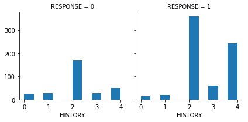

```python
g = sns.FacetGrid(df, col="RESPONSE")
g.map(plt.hist, "HISTORY");
```

```python
df.groupby('HISTORY').size() / len(df)
```

```
HISTORY
0    0.040
1    0.049
2    0.530
3    0.088
4    0.293
dtype: float64
```

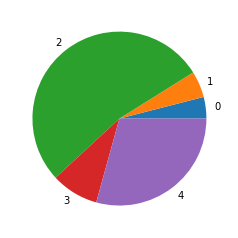

```python
g = df.groupby('HISTORY').size().reset_index()
plt.pie(g[0], labels=g['HISTORY']);
```

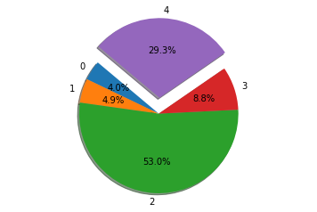

```python
# pie plot

explode = (0, 0, 0, 0, 0.2)  # explode 1st slice

plt.pie(g[0], labels=g['HISTORY'], explode=explode, autopct='%1.1f%%', shadow=True, startangle=140)

plt.axis('equal');
```

## Provide a discussion of the findings in a markdown

# Formulate your own question relevant to this dataset and business problem and answer using data visualization.

## Job could be an important variable predicting whether people will fulfill the credit agreement, so find out any relationship between job and response.

### 1st chart simply shows how many people per each category;

```python
df.groupby('JOB').size()
```

```
JOB
0     22
1    200
2    630
3    148
dtype: int64
```

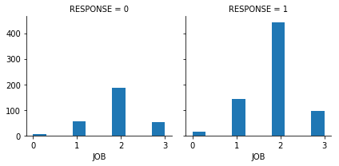

```python
g = sns.FacetGrid(df, col="RESPONSE")
g.map(plt.hist, "JOB");
```

```python
df.groupby('JOB').size() / len(df)
```

```
JOB
0    0.022
1    0.200
2    0.630
3    0.148
dtype: float64
```

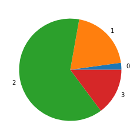

```python
g = df.groupby('JOB').size().reset_index()
plt.pie(g[0], labels=g['JOB']);
```

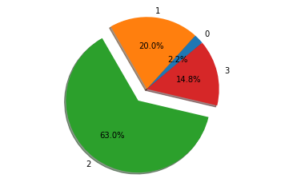

```python
# pie plot

explode = (0, 0, 0.2, 0,)  # explode 1st slice

plt.pie(g[0], labels=g['JOB'], explode=explode, autopct='%1.1f%%', shadow=True, startangle=40)

plt.axis('equal');
```

# Formulate your own question relevant to this dataset and business problem and answer using data visualization.

## Employment could be an important variable predicting whether people will fulfill the credit agreement, so find out any relationship between employment and response.

### 1st chart simply shows how many people per each category

```python
df.groupby('EMPLOYMENT').size()
```

```
EMPLOYMENT
0     62
1    172
2    339
3    174
4    253
dtype: int64
```

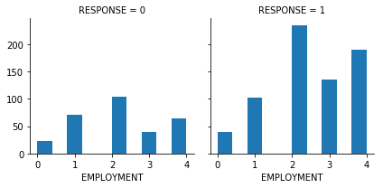

```python
g = sns.FacetGrid(df, col="RESPONSE")
g.map(plt.hist, "EMPLOYMENT");
```

```python
df.groupby('EMPLOYMENT').size() / len(df)
```

```
EMPLOYMENT
0    0.062
1    0.172
2    0.339
3    0.174
4    0.253
dtype: float64
```

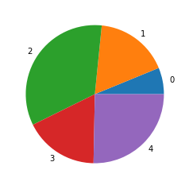

```python
g = df.groupby('EMPLOYMENT').size().reset_index()
plt.pie(g[0], labels=g['EMPLOYMENT']);
```

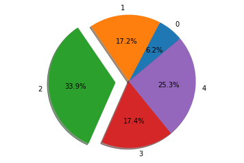

```python
# pie plot

explode = (0, 0, 0.2, 0, 0)  # explode 1st slice

plt.pie(g[0], labels=g['EMPLOYMENT'], explode=explode, autopct='%1.1f%%', shadow=True, startangle=40)

plt.axis('equal');
```

# Be very specific. What are the characteristics of the people who have paid back? Be very specific. What are the characteristics of the people who have defaulted on loans?